# Risk Factor Analysis

## Outcome Variable

**Outcome Variable:** pers_wasted624

## Predictor Variables

**Intervention Variable:** ever_swasted06

**Adjustment Set:**

- sex
- arm
- brthmon
- vagbrth
- single
- W_mage
- W_mhtcm
- W_mwtkg
- W_mbmi
- W_meducyrs
- W_feducyrs
- W_parity
- delta_brthmon
- delta_vagbrth
- delta_single
- delta_W_mage
- delta_W_mhtcm
- delta_W_mwtkg
- delta_W_mbmi
- delta_W_meducyrs
- delta_W_feducyrs
- delta_W_parity

## Stratifying Variables

The analysis was stratified on these variable(s):

- studyid
- country

## Data Summary

| studyid | country | ever_swasted06 | pers_wasted624 | n_cell | n |
| --- | --- | --- | --- | --- | --- |
| ki0047075b-MAL-ED | BANGLADESH | 0 | 0 | 211 | 240 |
| ki0047075b-MAL-ED | BANGLADESH | 0 | 1 | 13 | 240 |
| ki0047075b-MAL-ED | BANGLADESH | 1 | 0 | 12 | 240 |
| ki0047075b-MAL-ED | BANGLADESH | 1 | 1 | 4 | 240 |
| ki0047075b-MAL-ED | BRAZIL | 0 | 0 | 203 | 207 |
| ki0047075b-MAL-ED | BRAZIL | 0 | 1 | 1 | 207 |
| ki0047075b-MAL-ED | BRAZIL | 1 | 0 | 2 | 207 |
| ki0047075b-MAL-ED | BRAZIL | 1 | 1 | 1 | 207 |
| ki0047075b-MAL-ED | INDIA | 0 | 0 | 198 | 235 |
| ki0047075b-MAL-ED | INDIA | 0 | 1 | 16 | 235 |
| ki0047075b-MAL-ED | INDIA | 1 | 0 | 9 | 235 |
| ki0047075b-MAL-ED | INDIA | 1 | 1 | 12 | 235 |
| ki0047075b-MAL-ED | NEPAL | 0 | 0 | 227 | 235 |
| ki0047075b-MAL-ED | NEPAL | 0 | 1 | 1 | 235 |
| ki0047075b-MAL-ED | NEPAL | 1 | 0 | 6 | 235 |
| ki0047075b-MAL-ED | NEPAL | 1 | 1 | 1 | 235 |
| ki0047075b-MAL-ED | PERU | 0 | 0 | 266 | 270 |
| ki0047075b-MAL-ED | PERU | 0 | 1 | 3 | 270 |
| ki0047075b-MAL-ED | PERU | 1 | 0 | 1 | 270 |
| ki0047075b-MAL-ED | PERU | 1 | 1 | 0 | 270 |
| ki0047075b-MAL-ED | SOUTH AFRICA | 0 | 0 | 251 | 259 |
| ki0047075b-MAL-ED | SOUTH AFRICA | 0 | 1 | 1 | 259 |
| ki0047075b-MAL-ED | SOUTH AFRICA | 1 | 0 | 6 | 259 |
| ki0047075b-MAL-ED | SOUTH AFRICA | 1 | 1 | 1 | 259 |
| ki0047075b-MAL-ED | TANZANIA, UNITED REPUBLIC OF | 0 | 0 | 240 | 245 |
| ki0047075b-MAL-ED | TANZANIA, UNITED REPUBLIC OF | 0 | 1 | 0 | 245 |
| ki0047075b-MAL-ED | TANZANIA, UNITED REPUBLIC OF | 1 | 0 | 5 | 245 |
| ki0047075b-MAL-ED | TANZANIA, UNITED REPUBLIC OF | 1 | 1 | 0 | 245 |
| ki1000108-CMC-V-BCS-2002 | INDIA | 0 | 0 | 287 | 370 |
| ki1000108-CMC-V-BCS-2002 | INDIA | 0 | 1 | 14 | 370 |

[output cut: 90 more lines]

The following strata were considered:

- studyid: ki0047075b-MAL-ED, country: BANGLADESH
- studyid: ki0047075b-MAL-ED, country: BRAZIL
- studyid: ki0047075b-MAL-ED, country: INDIA
- studyid: ki0047075b-MAL-ED, country: NEPAL
- studyid: ki0047075b-MAL-ED, country: PERU
- studyid: ki0047075b-MAL-ED, country: SOUTH AFRICA
- studyid: ki0047075b-MAL-ED, country: TANZANIA, UNITED REPUBLIC OF
- studyid: ki1000108-CMC-V-BCS-2002, country: INDIA
- studyid: ki1000108-IRC, country: INDIA
- studyid: ki1000109-EE, country: PAKISTAN
- studyid: ki1000109-ResPak, country: PAKISTAN
- studyid: ki1000304b-SAS-CompFeed, country: INDIA
- studyid: ki1000304b-SAS-FoodSuppl, country: INDIA
- studyid: ki1017093-NIH-Birth, country: BANGLADESH
- studyid: ki1017093b-PROVIDE, country: BANGLADESH
- studyid: ki1017093c-NIH-Crypto, country: BANGLADESH
- studyid: ki1066203-TanzaniaChild2, country: TANZANIA, UNITED REPUBLIC OF
- studyid: ki1101329-Keneba, country: GAMBIA
- studyid: ki1112895-Guatemala BSC, country: GUATEMALA
- studyid: ki1113344-GMS-Nepal, country: NEPAL
- studyid: ki1114097-CMIN, country: BANGLADESH
- studyid: ki1114097-CONTENT, country: PERU
- studyid: ki1119695-PROBIT, country: BELARUS
- studyid: ki1126311-ZVITAMBO, country: ZIMBABWE
- studyid: ki1135781-COHORTS, country: GUATEMALA
- studyid: ki1135781-COHORTS, country: INDIA
- studyid: ki1135781-COHORTS, country: PHILIPPINES
- studyid: ki1148112-LCNI-5, country: MALAWI
- studyid: kiGH5241-JiVitA-3, country: BANGLADESH
- studyid: kiGH5241-JiVitA-4, country: BANGLADESH

### Dropped Strata

Some strata were dropped due to rare outcomes:

- studyid: ki0047075b-MAL-ED, country: BANGLADESH
- studyid: ki0047075b-MAL-ED, country: BRAZIL
- studyid: ki0047075b-MAL-ED, country: NEPAL
- studyid: ki0047075b-MAL-ED, country: PERU
- studyid: ki0047075b-MAL-ED, country: SOUTH AFRICA
- studyid: ki0047075b-MAL-ED, country: TANZANIA, UNITED REPUBLIC OF
- studyid: ki1112895-Guatemala BSC, country: GUATEMALA
- studyid: ki1114097-CONTENT, country: PERU
- studyid: ki1135781-COHORTS, country: GUATEMALA
- studyid: ki1148112-LCNI-5, country: MALAWI

## Methods Detail

We’re interested in the causal parameters $E[Y_a]$ for all values of $a \in \mathcal{A}$. These parameters represent the mean outcome if, possibly contrary to fact, we intervened to set all units to have $A=a$. Under the randomization and positivity assumptions, these are identified by the statistical parameters $\psi_a=E_W[E_{Y|A,W}(Y|A=a,W)]$. In addition, we’re interested in the mean of $Y$, $E[Y]$ under no intervention (the observed mean). We will estimate these parameters by using SuperLearner to fit the relevant likelihood factors – $E_{Y|A,W}(Y|A=a,W)$ and $p(A=a|W)$, and then updating our likelihood fit using a joint TMLE.

For unadjusted analyses ($W=\{\}$), initial likelihoods were estimated using Lrnr_glm to estimate the simple $E(Y|A)$ and Lrnr_mean to estimate $p(A)$. For adjusted analyses, a small library containing Lrnr_glmnet, Lrnr_xgboost, and Lrnr_mean was used.

Having estimated these parameters, we will then use the delta method to estimate relative risks and attributable risks relative to a prespecified baseline level of $A$.

# Results Detail

## Results Plots

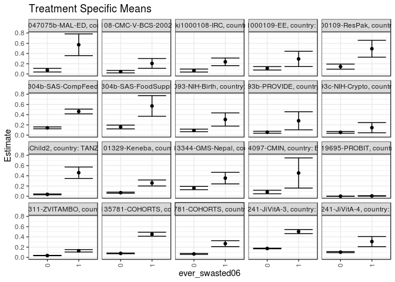

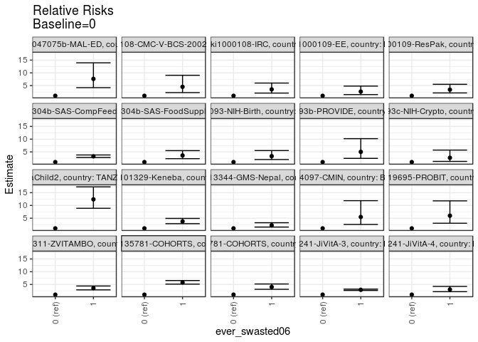

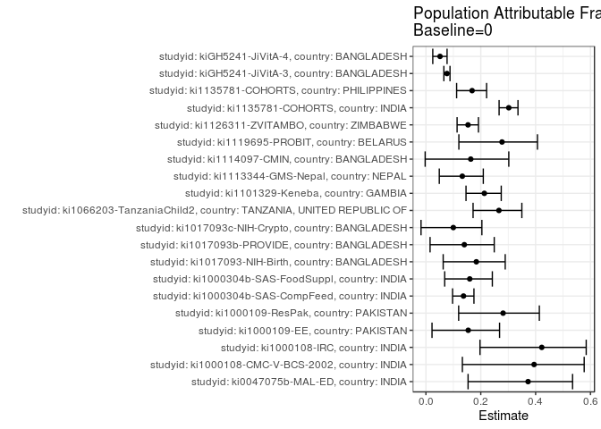

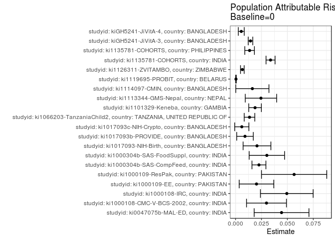

## Results Table

### Parameter: TSM

| studyid | country | intervention_level | baseline_level | estimate | ci_lower | ci_upper |
| --- | --- | --- | --- | --- | --- | --- |
| ki0047075b-MAL-ED | INDIA | 0 | NA | 0.0747664 | 0.0394524 | 0.1100803 |
| ki0047075b-MAL-ED | INDIA | 1 | NA | 0.5714286 | 0.3593206 | 0.7835366 |
| ki1000108-CMC-V-BCS-2002 | INDIA | 0 | NA | 0.0458286 | 0.0222156 | 0.0694416 |
| ki1000108-CMC-V-BCS-2002 | INDIA | 1 | NA | 0.2068054 | 0.1106667 | 0.3029442 |
| ki1000108-IRC | INDIA | 0 | NA | 0.0676237 | 0.0384804 | 0.0967670 |
| ki1000108-IRC | INDIA | 1 | NA | 0.2378024 | 0.1634531 | 0.3121516 |
| ki1000109-EE | PAKISTAN | 0 | NA | 0.1108046 | 0.0770978 | 0.1445114 |
| ki1000109-EE | PAKISTAN | 1 | NA | 0.2947664 | 0.1455634 | 0.4439694 |
| ki1000109-ResPak | PAKISTAN | 0 | NA | 0.1443394 | 0.0950609 | 0.1936179 |
| ki1000109-ResPak | PAKISTAN | 1 | NA | 0.4937117 | 0.3284911 | 0.6589323 |
| ki1000304b-SAS-CompFeed | INDIA | 0 | NA | 0.1421685 | 0.1235170 | 0.1608201 |
| ki1000304b-SAS-CompFeed | INDIA | 1 | NA | 0.4625415 | 0.4161502 | 0.5089327 |
| ki1000304b-SAS-FoodSuppl | INDIA | 0 | NA | 0.1588483 | 0.1217024 | 0.1959942 |
| ki1000304b-SAS-FoodSuppl | INDIA | 1 | NA | 0.5698870 | 0.3675428 | 0.7722311 |
| ki1017093-NIH-Birth | BANGLADESH | 0 | NA | 0.0918586 | 0.0662654 | 0.1174518 |
| ki1017093-NIH-Birth | BANGLADESH | 1 | NA | 0.3054146 | 0.1763087 | 0.4345205 |
| ki1017093b-PROVIDE | BANGLADESH | 0 | NA | 0.0559322 | 0.0373752 | 0.0744892 |
| ki1017093b-PROVIDE | BANGLADESH | 1 | NA | 0.2800000 | 0.1038524 | 0.4561476 |
| ki1017093c-NIH-Crypto | BANGLADESH | 0 | NA | 0.0542522 | 0.0372404 | 0.0712640 |
| ki1017093c-NIH-Crypto | BANGLADESH | 1 | NA | 0.1458333 | 0.0459197 | 0.2457470 |
| ki1066203-TanzaniaChild2 | TANZANIA, UNITED REPUBLIC OF | 0 | NA | 0.0370888 | 0.0286875 | 0.0454902 |
| ki1066203-TanzaniaChild2 | TANZANIA, UNITED REPUBLIC OF | 1 | NA | 0.4597006 | 0.3482468 | 0.5711545 |
| ki1101329-Keneba | GAMBIA | 0 | NA | 0.0695198 | 0.0586009 | 0.0804387 |
| ki1101329-Keneba | GAMBIA | 1 | NA | 0.2594245 | 0.2010251 | 0.3178238 |
| ki1113344-GMS-Nepal | NEPAL | 0 | NA | 0.1602382 | 0.1285350 | 0.1919414 |
| ki1113344-GMS-Nepal | NEPAL | 1 | NA | 0.3541993 | 0.2415297 | 0.4668689 |
| ki1114097-CMIN | BANGLADESH | 0 | NA | 0.0829876 | 0.0480898 | 0.1178853 |
| ki1114097-CMIN | BANGLADESH | 1 | NA | 0.4545455 | 0.1597077 | 0.7493832 |
| ki1119695-PROBIT | BELARUS | 0 | NA | 0.0010449 | 0.0002971 | 0.0017926 |
| ki1119695-PROBIT | BELARUS | 1 | NA | 0.0062354 | 0.0009301 | 0.0115407 |
| ki1126311-ZVITAMBO | ZIMBABWE | 0 | NA | 0.0360508 | 0.0323985 | 0.0397030 |
| ki1126311-ZVITAMBO | ZIMBABWE | 1 | NA | 0.1282742 | 0.1044314 | 0.1521170 |
| ki1135781-COHORTS | INDIA | 0 | NA | 0.0779741 | 0.0713564 | 0.0845918 |
| ki1135781-COHORTS | INDIA | 1 | NA | 0.4521116 | 0.4128462 | 0.4913770 |
| ki1135781-COHORTS | PHILIPPINES | 0 | NA | 0.0669332 | 0.0573285 | 0.0765379 |
| ki1135781-COHORTS | PHILIPPINES | 1 | NA | 0.2684904 | 0.2105703 | 0.3264104 |
| kiGH5241-JiVitA-3 | BANGLADESH | 0 | NA | 0.1735893 | 0.1673069 | 0.1798717 |
| kiGH5241-JiVitA-3 | BANGLADESH | 1 | NA | 0.5043848 | 0.4643099 | 0.5444596 |
| kiGH5241-JiVitA-4 | BANGLADESH | 0 | NA | 0.1017559 | 0.0913970 | 0.1121149 |
| kiGH5241-JiVitA-4 | BANGLADESH | 1 | NA | 0.3089712 | 0.2100015 | 0.4079409 |

### Parameter: E(Y)

| studyid | country | intervention_level | baseline_level | estimate | ci_lower | ci_upper |
| --- | --- | --- | --- | --- | --- | --- |
| ki0047075b-MAL-ED | INDIA | NA | NA | 0.1191489 | 0.0776405 | 0.1606574 |
| ki1000108-CMC-V-BCS-2002 | INDIA | NA | NA | 0.0756757 | 0.0486905 | 0.1026609 |
| ki1000108-IRC | INDIA | NA | NA | 0.1170732 | 0.0859146 | 0.1482317 |
| ki1000109-EE | PAKISTAN | NA | NA | 0.1310160 | 0.0967738 | 0.1652583 |
| ki1000109-ResPak | PAKISTAN | NA | NA | 0.2008547 | 0.1494120 | 0.2522974 |
| ki1000304b-SAS-CompFeed | INDIA | NA | NA | 0.1647399 | 0.1451050 | 0.1843747 |
| ki1000304b-SAS-FoodSuppl | INDIA | NA | NA | 0.1890547 | 0.1507312 | 0.2273783 |
| ki1017093-NIH-Birth | BANGLADESH | NA | NA | 0.1125461 | 0.0859151 | 0.1391771 |
| ki1017093b-PROVIDE | BANGLADESH | NA | NA | 0.0650407 | 0.0455353 | 0.0845460 |
| ki1017093c-NIH-Crypto | BANGLADESH | NA | NA | 0.0602740 | 0.0429977 | 0.0775502 |
| ki1066203-TanzaniaChild2 | TANZANIA, UNITED REPUBLIC OF | NA | NA | 0.0505451 | 0.0409848 | 0.0601054 |
| ki1101329-Keneba | GAMBIA | NA | NA | 0.0883377 | 0.0767324 | 0.0999430 |
| ki1113344-GMS-Nepal | NEPAL | NA | NA | 0.1847458 | 0.1534039 | 0.2160876 |
| ki1114097-CMIN | BANGLADESH | NA | NA | 0.0992063 | 0.0622241 | 0.1361886 |
| ki1119695-PROBIT | BELARUS | NA | NA | 0.0014461 | 0.0004206 | 0.0024716 |
| ki1126311-ZVITAMBO | ZIMBABWE | NA | NA | 0.0425869 | 0.0387663 | 0.0464075 |
| ki1135781-COHORTS | INDIA | NA | NA | 0.1117237 | 0.1042858 | 0.1191617 |
| ki1135781-COHORTS | PHILIPPINES | NA | NA | 0.0804843 | 0.0704205 | 0.0905481 |
| kiGH5241-JiVitA-3 | BANGLADESH | NA | NA | 0.1880070 | 0.1814627 | 0.1945512 |
| kiGH5241-JiVitA-4 | BANGLADESH | NA | NA | 0.1072724 | 0.0967392 | 0.1178055 |

### Parameter: RR

| studyid | country | intervention_level | baseline_level | estimate | ci_lower | ci_upper |
| --- | --- | --- | --- | --- | --- | --- |
| ki0047075b-MAL-ED | INDIA | 0 | 0 | 1.000000 | 1.000000 | 1.000000 |
| ki0047075b-MAL-ED | INDIA | 1 | 0 | 7.642857 | 4.191447 | 13.936300 |
| ki1000108-CMC-V-BCS-2002 | INDIA | 0 | 0 | 1.000000 | 1.000000 | 1.000000 |
| ki1000108-CMC-V-BCS-2002 | INDIA | 1 | 0 | 4.512582 | 2.251911 | 9.042716 |
| ki1000108-IRC | INDIA | 0 | 0 | 1.000000 | 1.000000 | 1.000000 |
| ki1000108-IRC | INDIA | 1 | 0 | 3.516555 | 2.062226 | 5.996510 |
| ki1000109-EE | PAKISTAN | 0 | 0 | 1.000000 | 1.000000 | 1.000000 |
| ki1000109-EE | PAKISTAN | 1 | 0 | 2.660236 | 1.473929 | 4.801355 |
| ki1000109-ResPak | PAKISTAN | 0 | 0 | 1.000000 | 1.000000 | 1.000000 |
| ki1000109-ResPak | PAKISTAN | 1 | 0 | 3.420492 | 2.125896 | 5.503451 |
| ki1000304b-SAS-CompFeed | INDIA | 0 | 0 | 1.000000 | 1.000000 | 1.000000 |
| ki1000304b-SAS-CompFeed | INDIA | 1 | 0 | 3.253473 | 2.793448 | 3.789254 |
| ki1000304b-SAS-FoodSuppl | INDIA | 0 | 0 | 1.000000 | 1.000000 | 1.000000 |
| ki1000304b-SAS-FoodSuppl | INDIA | 1 | 0 | 3.587618 | 2.342007 | 5.495716 |
| ki1017093-NIH-Birth | BANGLADESH | 0 | 0 | 1.000000 | 1.000000 | 1.000000 |
| ki1017093-NIH-Birth | BANGLADESH | 1 | 0 | 3.324835 | 2.003467 | 5.517699 |
| ki1017093b-PROVIDE | BANGLADESH | 0 | 0 | 1.000000 | 1.000000 | 1.000000 |
| ki1017093b-PROVIDE | BANGLADESH | 1 | 0 | 5.006061 | 2.458188 | 10.194764 |
| ki1017093c-NIH-Crypto | BANGLADESH | 0 | 0 | 1.000000 | 1.000000 | 1.000000 |
| ki1017093c-NIH-Crypto | BANGLADESH | 1 | 0 | 2.688063 | 1.265352 | 5.710413 |
| ki1066203-TanzaniaChild2 | TANZANIA, UNITED REPUBLIC OF | 0 | 0 | 1.000000 | 1.000000 | 1.000000 |
| ki1066203-TanzaniaChild2 | TANZANIA, UNITED REPUBLIC OF | 1 | 0 | 12.394589 | 8.891980 | 17.276898 |
| ki1101329-Keneba | GAMBIA | 0 | 0 | 1.000000 | 1.000000 | 1.000000 |
| ki1101329-Keneba | GAMBIA | 1 | 0 | 3.731664 | 2.837918 | 4.906877 |
| ki1113344-GMS-Nepal | NEPAL | 0 | 0 | 1.000000 | 1.000000 | 1.000000 |
| ki1113344-GMS-Nepal | NEPAL | 1 | 0 | 2.210455 | 1.520408 | 3.213684 |
| ki1114097-CMIN | BANGLADESH | 0 | 0 | 1.000000 | 1.000000 | 1.000000 |
| ki1114097-CMIN | BANGLADESH | 1 | 0 | 5.477273 | 2.528380 | 11.865507 |
| ki1119695-PROBIT | BELARUS | 0 | 0 | 1.000000 | 1.000000 | 1.000000 |
| ki1119695-PROBIT | BELARUS | 1 | 0 | 5.967654 | 3.017791 | 11.800979 |
| ki1126311-ZVITAMBO | ZIMBABWE | 0 | 0 | 1.000000 | 1.000000 | 1.000000 |
| ki1126311-ZVITAMBO | ZIMBABWE | 1 | 0 | 3.558153 | 2.880270 | 4.395579 |
| ki1135781-COHORTS | INDIA | 0 | 0 | 1.000000 | 1.000000 | 1.000000 |
| ki1135781-COHORTS | INDIA | 1 | 0 | 5.798227 | 5.137223 | 6.544283 |
| ki1135781-COHORTS | PHILIPPINES | 0 | 0 | 1.000000 | 1.000000 | 1.000000 |
| ki1135781-COHORTS | PHILIPPINES | 1 | 0 | 4.011320 | 3.099563 | 5.191276 |
| kiGH5241-JiVitA-3 | BANGLADESH | 0 | 0 | 1.000000 | 1.000000 | 1.000000 |
| kiGH5241-JiVitA-3 | BANGLADESH | 1 | 0 | 2.905621 | 2.666753 | 3.165886 |
| kiGH5241-JiVitA-4 | BANGLADESH | 0 | 0 | 1.000000 | 1.000000 | 1.000000 |
| kiGH5241-JiVitA-4 | BANGLADESH | 1 | 0 | 3.036395 | 2.172991 | 4.242859 |

### Parameter: PAR

| studyid | country | intervention_level | baseline_level | estimate | ci_lower | ci_upper |
| --- | --- | --- | --- | --- | --- | --- |
| ki0047075b-MAL-ED | INDIA | 0 | NA | 0.0443826 | 0.0179485 | 0.0708166 |
| ki1000108-CMC-V-BCS-2002 | INDIA | 0 | NA | 0.0298470 | 0.0105893 | 0.0491048 |
| ki1000108-IRC | INDIA | 0 | NA | 0.0494495 | 0.0240083 | 0.0748907 |
| ki1000109-EE | PAKISTAN | 0 | NA | 0.0202114 | 0.0035019 | 0.0369210 |
| ki1000109-ResPak | PAKISTAN | 0 | NA | 0.0565153 | 0.0250187 | 0.0880119 |
| ki1000304b-SAS-CompFeed | INDIA | 0 | NA | 0.0225714 | 0.0158434 | 0.0292993 |
| ki1000304b-SAS-FoodSuppl | INDIA | 0 | NA | 0.0302064 | 0.0131216 | 0.0472913 |
| ki1017093-NIH-Birth | BANGLADESH | 0 | NA | 0.0206875 | 0.0072676 | 0.0341074 |
| ki1017093b-PROVIDE | BANGLADESH | 0 | NA | 0.0091084 | 0.0011028 | 0.0171141 |
| ki1017093c-NIH-Crypto | BANGLADESH | 0 | NA | 0.0060218 | -0.0008431 | 0.0128867 |
| ki1066203-TanzaniaChild2 | TANZANIA, UNITED REPUBLIC OF | 0 | NA | 0.0134563 | 0.0083454 | 0.0185671 |
| ki1101329-Keneba | GAMBIA | 0 | NA | 0.0188179 | 0.0127176 | 0.0249182 |
| ki1113344-GMS-Nepal | NEPAL | 0 | NA | 0.0245075 | 0.0093680 | 0.0396471 |
| ki1114097-CMIN | BANGLADESH | 0 | NA | 0.0162188 | 0.0002139 | 0.0322237 |
| ki1119695-PROBIT | BELARUS | 0 | NA | 0.0004013 | 0.0000329 | 0.0007697 |
| ki1126311-ZVITAMBO | ZIMBABWE | 0 | NA | 0.0065361 | 0.0047850 | 0.0082872 |
| ki1135781-COHORTS | INDIA | 0 | NA | 0.0337496 | 0.0293988 | 0.0381004 |
| ki1135781-COHORTS | PHILIPPINES | 0 | NA | 0.0135512 | 0.0089027 | 0.0181996 |
| kiGH5241-JiVitA-3 | BANGLADESH | 0 | NA | 0.0144177 | 0.0122254 | 0.0166099 |
| kiGH5241-JiVitA-4 | BANGLADESH | 0 | NA | 0.0055165 | 0.0026653 | 0.0083677 |

### Parameter: PAF

| studyid | country | intervention_level | baseline_level | estimate | ci_lower | ci_upper |
| --- | --- | --- | --- | --- | --- | --- |
| ki0047075b-MAL-ED | INDIA | 0 | NA | 0.3724967 | 0.1536730 | 0.5347420 |
| ki1000108-CMC-V-BCS-2002 | INDIA | 0 | NA | 0.3944074 | 0.1329190 | 0.5770379 |
| ki1000108-IRC | INDIA | 0 | NA | 0.4223811 | 0.1971502 | 0.5844259 |
| ki1000109-EE | PAKISTAN | 0 | NA | 0.1542669 | 0.0222196 | 0.2684815 |
| ki1000109-ResPak | PAKISTAN | 0 | NA | 0.2813741 | 0.1193667 | 0.4135775 |
| ki1000304b-SAS-CompFeed | INDIA | 0 | NA | 0.1370121 | 0.0971847 | 0.1750824 |
| ki1000304b-SAS-FoodSuppl | INDIA | 0 | NA | 0.1597762 | 0.0684664 | 0.2421358 |
| ki1017093-NIH-Birth | BANGLADESH | 0 | NA | 0.1838139 | 0.0629190 | 0.2891119 |
| ki1017093b-PROVIDE | BANGLADESH | 0 | NA | 0.1400424 | 0.0151570 | 0.2490913 |
| ki1017093c-NIH-Crypto | BANGLADESH | 0 | NA | 0.0999067 | -0.0178485 | 0.2040388 |
| ki1066203-TanzaniaChild2 | TANZANIA, UNITED REPUBLIC OF | 0 | NA | 0.2662232 | 0.1719334 | 0.3497765 |
| ki1101329-Keneba | GAMBIA | 0 | NA | 0.2130224 | 0.1461954 | 0.2746189 |
| ki1113344-GMS-Nepal | NEPAL | 0 | NA | 0.1326555 | 0.0487156 | 0.2091887 |
| ki1114097-CMIN | BANGLADESH | 0 | NA | 0.1634855 | -0.0027793 | 0.3021829 |
| ki1119695-PROBIT | BELARUS | 0 | NA | 0.2774767 | 0.1201276 | 0.4066867 |
| ki1126311-ZVITAMBO | ZIMBABWE | 0 | NA | 0.1534771 | 0.1136539 | 0.1915111 |
| ki1135781-COHORTS | INDIA | 0 | NA | 0.3020811 | 0.2668119 | 0.3356537 |
| ki1135781-COHORTS | PHILIPPINES | 0 | NA | 0.1683701 | 0.1119234 | 0.2212289 |
| kiGH5241-JiVitA-3 | BANGLADESH | 0 | NA | 0.0766868 | 0.0654213 | 0.0878165 |
| kiGH5241-JiVitA-4 | BANGLADESH | 0 | NA | 0.0514247 | 0.0249990 | 0.0771343 |